# Homework 7

*Enter your name and EID here*

**This homework is due on April 12, 2021 at 11:00pm. Please submit as a pdf file on Canvas.**

For all problems in this homework, we will work with the `penguins_clean` dataset, which is a cleaned-up version of the `penguins` dataset from the **palmerpenguins** package.

**Note:** This homework is about the contents of the plots. Don’t worry about styling. It’s OK to use the default theme and plot labeling.

```r
library(palmerpenguins)

penguins_clean <- penguins %>%
  select(-year) %>% # remove the year column as it is distracting here
  na.omit()         # remove any rows with missing values

penguins_clean
```

```
## # A tibble: 333 x 7
##    species island bill_length_mm bill_depth_mm flipper_length_… body_mass_g
##    <fct>   <fct>           <dbl>         <dbl>            <int>       <int>
##  1 Adelie  Torge…           39.1          18.7              181        3750
##  2 Adelie  Torge…           39.5          17.4              186        3800
##  3 Adelie  Torge…           40.3          18                195        3250
##  4 Adelie  Torge…           36.7          19.3              193        3450
##  5 Adelie  Torge…           39.3          20.6              190        3650
##  6 Adelie  Torge…           38.9          17.8              181        3625
##  7 Adelie  Torge…           39.2          19.6              195        4675
##  8 Adelie  Torge…           41.1          17.6              182        3200
##  9 Adelie  Torge…           38.6          21.2              191        3800
## 10 Adelie  Torge…           34.6          21.1              198        4400
## # … with 323 more rows, and 1 more variable: sex <fct>
```

**Problem 1: (2 pts)**

Perform a PCA of the `penguins_clean` dataset and make two plots: 1. A rotation plot of components 1 and 2; 2. A plot of the eigenvalues, showing the amount of variance explained by the various components.

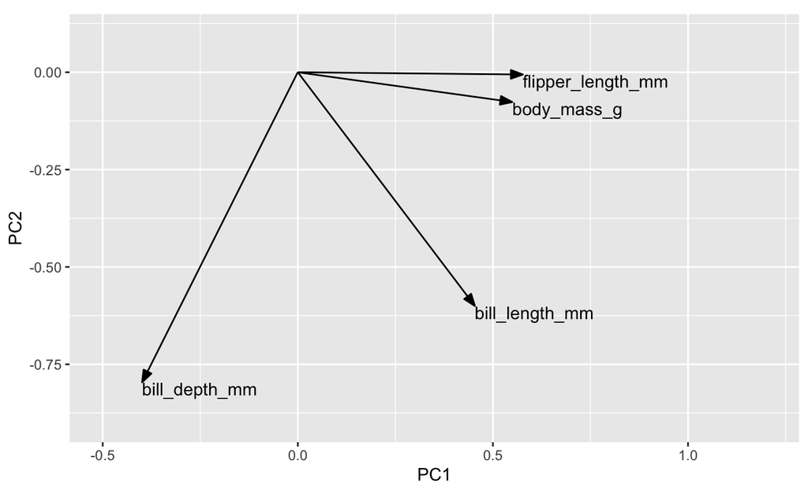

```r
# perform PCA
pca_fit <- penguins_clean %>%
  select(where(is.numeric)) %>% # retain only numeric columns
  scale() %>%                   # scale to zero mean and unit variance
  prcomp()

# make rotation plot
arrow_style <- arrow(
  angle = 20, length = grid::unit(8, "pt"),
  ends = "first", type = "closed"
)
pca_fit %>%
  # extract rotation matrix
  tidy(matrix = "rotation") %>%
  pivot_wider(
    names_from = "PC", values_from = "value",
    names_prefix = "PC"
  ) %>%
  ggplot(aes(PC1, PC2)) +
  geom_segment(
    xend = 0, yend = 0,
    arrow = arrow_style
  ) +
  geom_text(aes(label = column), hjust = 0, vjust = 1) +
  coord_fixed(xlim = c(-0.5, 1.2), ylim = c(-.9, .1))
```

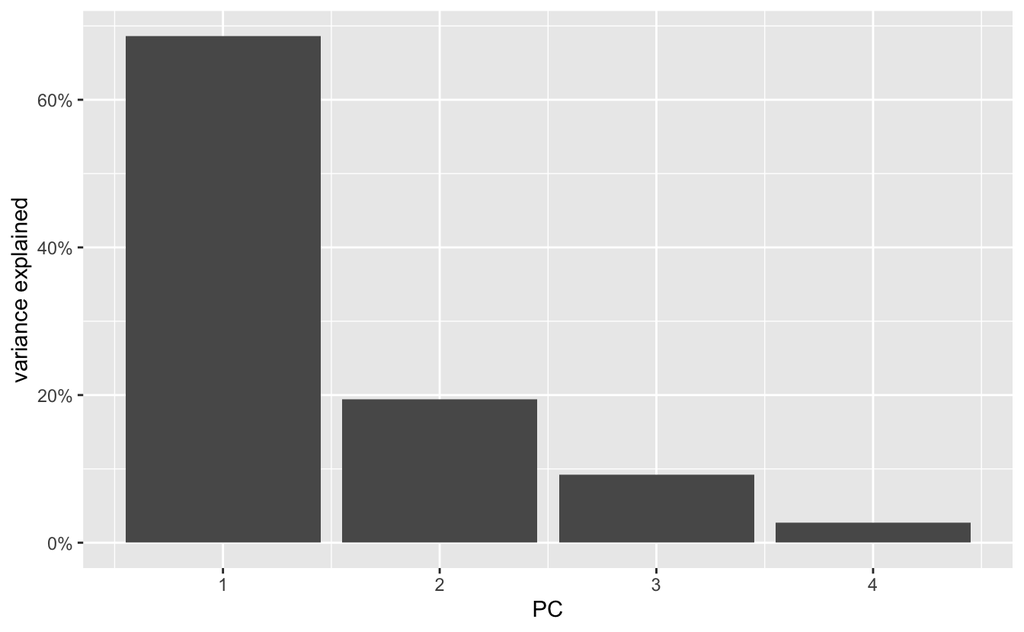

```r
# make variance explained plot
pca_fit %>%
  # extract eigenvalues
  tidy(matrix = "eigenvalues") %>%
  ggplot(aes(PC, percent)) +
  geom_col() +
  scale_x_continuous(
    # create one axis tick per PC
    breaks = 1:4
  ) +
  scale_y_continuous(
    name = "variance explained",
    # format y axis ticks as percent values
    label = scales::label_percent(accuracy = 1)
  )
```

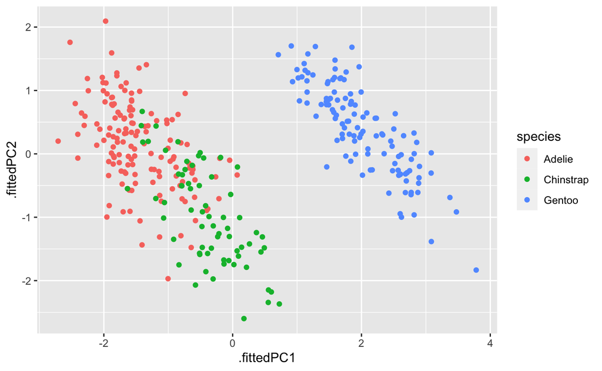

```r
pca_fit %>%
  # add PCs to the original dataset
  augment(penguins_clean) %>%
  ggplot(aes(.fittedPC1, .fittedPC2)) +
  geom_point(aes(color = species))
```

Supporting plot:

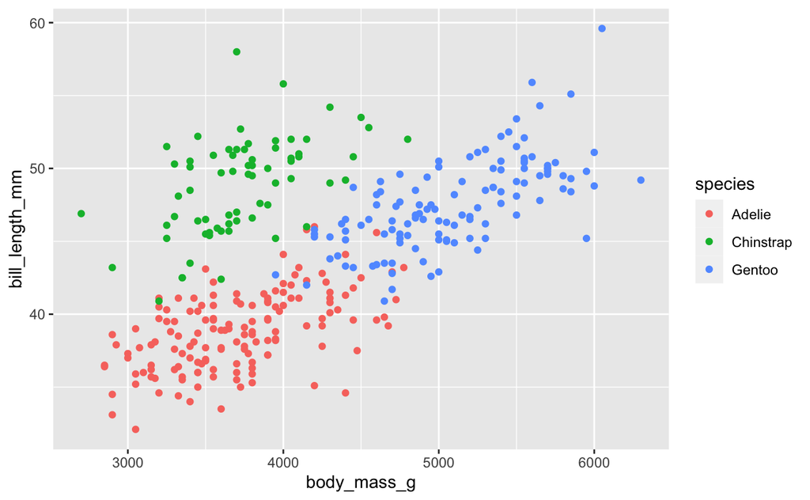

```r
penguins_clean %>%
  ggplot(aes(body_mass_g, bill_length_mm)) +
  geom_point(aes(color = species))
```

**Problem 3: (4 pts)** Again make a scatter plot of PC 2 versus PC 1, but now color by sex. Then use the rotation plot from Problem 1 to describe the physical characteristics by which the different penguin sexes differ. Finally, make one more scatter plot of the raw data that can support your interpretation of the PC analysis.

**Hint:** It helps to facet by penguin species.

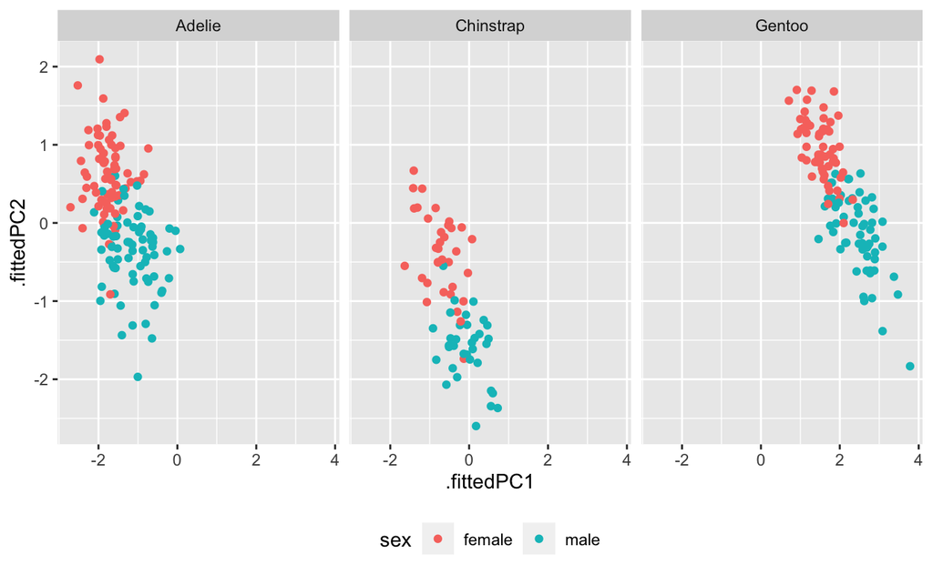

```r
pca_fit %>%
  # add PCs to the original dataset
  augment(penguins_clean) %>%
  ggplot(aes(.fittedPC1, .fittedPC2)) +
  geom_point(aes(color = sex)) +
  facet_wrap(vars(species)) +
  theme(legend.position = "bottom")
```

We see that female penguins have smaller PC 1 values and larger PC 2 values than male penguins. This suggests female penguins have shorter and narrower bills, i.e., they have on average smaller bills than male penguins.

Supporting plot:

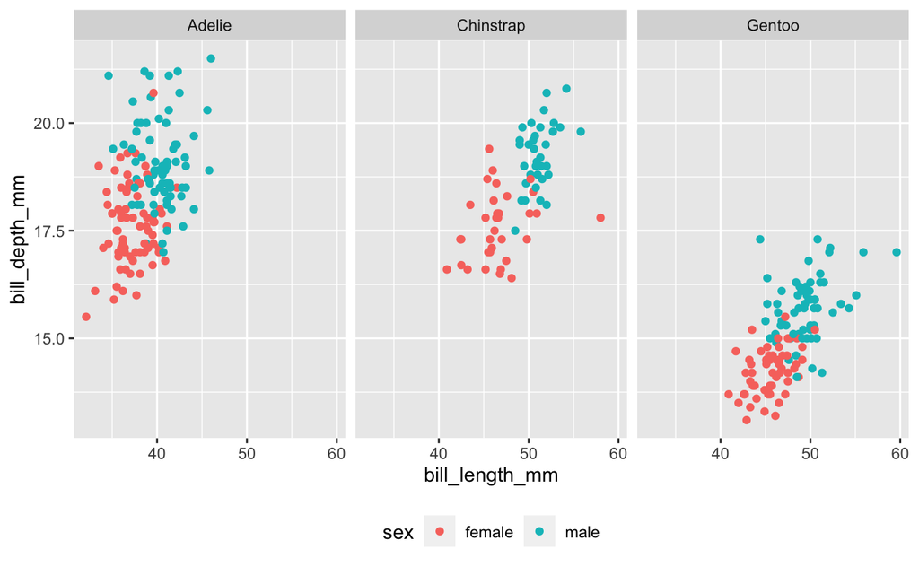

```r
penguins_clean %>%
  ggplot(aes(bill_length_mm, bill_depth_mm)) +
  geom_point(aes(color = sex)) +
  facet_wrap(vars(species)) +
  theme(legend.position = "bottom")
```